# Лабораторийн ажил 5-6

## Өгөгдлийн урьдчилсан боловсруулалт

Өгөгдлийн урьдчилсан боловсруулалт нь өгөгдөл олборлох шинжилгээг сайжруулахын тулд өгөгдлийг цэвэрлэх (cleaning), сонгох (selecting), хувиргах (transforming) өргөн хүрээний техникүүдээс бүрддэг.

### 1. Өгөгдлийн чанарын асуудал

Өгөгдлийн чанар муу байх нь өгөгдөл олборлолтод сөргөөр нөлөөлнө. Өгөгдлийн чанартай холбоотой нийтлэг асуудлуудад шуугиан (noise), хэвийн бус утга (outliers), дутуу утга (missing values), давхардсан өгөгдөл (duplicate data) ордог. Энэ хэсэгт өгөгдлийн чанарын зарим асуудлыг шийдэх Python кодын жишээг үзүүлэв.

Хөхний хорт хавдартай өвчтөнүүдийн талаарх мэдээллийг агуулсан UCI машин сургалтын өгөгдлийн багцыг ашиглая. Бид эхлээд Pandas read_csv() функцийг ашиглан өгөгдлийн багцыг татаж аван, эхний 5 өгөгдлийн цэгийг харуулна.

```python
import pandas as pd
data = pd.read_csv('https://archive.ics.uci.edu/ml/machine-learning-databases/breast-cancer-wisconsin/breast-cancer-wisconsin.data', header=None)
data.columns = ['Sample code', 'Clump Thickness', 'Uniformity of Cell Size', 'Uniformity of Cell Shape',
                'Marginal Adhesion', 'Single Epithelial Cell Size', 'Bare Nuclei', 'Bland Chromatin',
                'Normal Nucleoli', 'Mitoses','Class']

data = data.drop(['Sample code'],axis=1)
print('Бичлэгийн тоо = %d' % (data.shape[0]))
print('Атрибутын тоо = %d' % (data.shape[1]))
data.head()
```

```
Бичлэгийн тоо = 699
Атрибутын тоо = 10
```

|  | Clump Thickness | Uniformity of Cell Size | Uniformity of Cell Shape | Marginal Adhesion | Single Epithelial Cell Size | Bare Nuclei | Bland Chromatin | Normal Nucleoli | Mitoses | Class |
| --- | --- | --- | --- | --- | --- | --- | --- | --- | --- | --- |
| 0 | 5 | 1 | 1 | 1 | 2 | 1 | 3 | 1 | 1 | 2 |
| 1 | 5 | 4 | 4 | 5 | 7 | 10 | 3 | 2 | 1 | 2 |
| 2 | 3 | 1 | 1 | 1 | 2 | 2 | 3 | 1 | 1 | 2 |
| 3 | 6 | 8 | 8 | 1 | 3 | 4 | 3 | 7 | 1 | 2 |
| 4 | 4 | 1 | 1 | 3 | 2 | 1 | 3 | 1 | 1 | 2 |

```python
data.info()
```

```python
data.dtypes
```

### 2. Дутуу утгууд - Missing values

Обьектын нэг эсвэл хэд хэдэн атрибутуудын утга дутуу байх нь ердийн зүйл биш юм. Энэ хэсэгт дутуу утгыг зохицуулах янз бүрийн аргын жишээг үзүүлэв. Дутуу буюу бөглөгдөөгүй утгуудад өөр утга оноох эсвэл эдгээр дутуу утгатай бичлэгийг устгаж болно. Өгөгдлийн тайлбар мэдээллийн дагуу дутуу буюу бөглөгдөөгүй утгууд анхны өгөгдөлд **'?'** гэж кодлогдсон байна. Иймд дутуу утгыг **NaN** болгон хувиргаж, дараа нь өгөгдлийн багана бүр дэх дутуу утгын тоог олъё.

```python
import numpy as np

data = data.replace('?',np.NaN)

print('Бичлэгийн тоо = %d' % (data.shape[0]))
print('Атрибутын тоо = %d' % (data.shape[1]))

print('Дутуу утгуудын тоо:')
for col in data.columns:
    print('\t%s: %d' % (col,data[col].isna().sum()))
```

**Утга оноох**

```python
data2 = data['Bare Nuclei']

print('Солихын өмнөх утга:')
print(data2[20:25])
data2 = data2.fillna(data2.median())

print('\nСолисны дараах утга:')
print(data2[20:25])
```

**Мөр устгах**

Дутуу утгуудад тухайн атрибутын медиан, дундаж гэх мэт утгыг оноохын оронд, өөр нэг нийтлэг хэрэглэдэг арга бол дутуу утгыг агуулсан өгөгдлийн цэгүүдийг хаях явдал юм. **dropna()** функцийг ашиглан хоосон утгатай мөрүүдийг хялбархан устгана.

```python
print('Бичлэгийн тоо = %d' % (data.shape[0]))

data2 = data.dropna()
print('Мөр устгасны дараах нийт бичлэгийн тоо = %d' % (data2.shape[0]))
```

### 3. Хэвийн биш утгууд - Outliers

Outliers нь өгөгдлийн бусад утгуудаас эрс ялгаатай шинж чанартай өгөгдлийн тохиолдол юм. Outliers утгыг агуулсан багануудыг тодорхойлохын тулд **boxplot** диаграммыг байгуулъя. Бүх баганын утгууд ("Bare Nuclei"-ээс бусад) тоон утгатай ('int64') бол "Bare Nuclei" баганын утгууд нь тэмдэгт мөр обьектууд (уг баганад анх '?' тэмдэгт мөр нь дутуу утгыг илэрхийлж байсан) байна. Иймд **boxplot** диаграмыг үүсгэхийн өмнө энэ баганын утгыг тоон утга болгон хувиргах ёстой, үгүй бол уг багана **boxplot**-г зурах үед дүрслэгдэхгүй.

```python
%matplotlib inline

data2 = data.drop(['Class'],axis=1)
data2['Bare Nuclei'] = pd.to_numeric(data2['Bare Nuclei'])
data2.boxplot(figsize=(20,3))
```

[output not shown]

```python
Z = (data2-data2.mean())/data2.std()
Z[20:25]
```

Z > 3 эсвэл Z <= -3 байх утгуудыг устгана.

```python
print('Number of rows before discarding outliers = %d' % (Z.shape[0]))
Z2 = Z.loc[((Z > -3).sum(axis=1)==9) & ((Z <= 3).sum(axis=1)==9),:]
print('Number of rows after discarding missing values = %d' % (Z2.shape[0]))
```

### 4. Өгөгдлийн давхардал - Duplicate Data

Зарим өгөгдлийн багц, ялангуяа олон өгөгдлийн эх сурвалжийг нэгтгэснээр олж авсан өгөгдлийн багц нь давхардсан тохиолдлуудыг агуулж болно.

Дараах жишээнд бид эхлээд хөхний хорт хавдрын өгөгдлийн багцад давхардсан тохиолдлууд байгаа эсэхийг шалгана.

```python
dups = data.duplicated()
print('Number of duplicate rows = %d' % (dups.sum()))
data.loc[[11,28]]
```

```python
print('Number of rows before discarding duplicates = %d' % (data.shape[0]))
data2 = data.drop_duplicates()
print('Number of rows after discarding duplicates = %d' % (data2.shape[0]))
```

### 5. Нэгтгэх - Aggregation

Өгөгдлийг нэгтгэх нь хоёр болон түүнээс дээш объектын утгыг нэг объект болгон нэгтгэх урьдчилсан боловсруулалтын ажил юм. Энэ нь

- Боловсруулах өгөгдлийн хэмжээг багасгах
- Шинжилгээний нарийвчлалыг өөрчлөх (нарийн масштабаас өргөн масштабруу)
- Өгөгдлийн тогтвортой байдлыг сайжруулах ач холбогдолтой.

Дараах жишээнд Detroit Metro нисэх онгоцны буудалд байрлах цаг уурын станцын өдөр тутмын хур тунадасны хугацааны цуваа өгөгдлийг ашиглана.  
Өгөгдөл: DTW_prec.csv файл  
Дараах код нь өгөгдлийг ачаалж, **line plot** зурна.

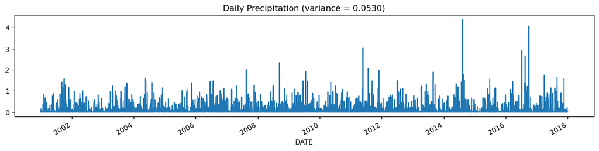

```python
daily = pd.read_csv('DTW_prec.csv', header='infer')
daily.index = pd.to_datetime(daily['DATE'])
daily = daily['PRCP']
ax = daily.plot(kind='line',figsize=(15,3))
ax.set_title('Daily Precipitation (variance = %.4f)' % (daily.var()))
```

Өдөр тутмын хугацааны цуваа нь нэлээд эмх замбараагүй бөгөөд нэг хугацааны агшнаас нөгөөд ихээхэн ялгаатай байгааг ажиглаарай. Сарын нийт хур тунадасны утгыг авахын тулд хугацааны цувааг сараар нь бүлэглэж, нэгтгэж болно. Үүссэн хугацааны цуваа нь өдөр тутмын хугацааны цуваатай харьцуулахад илүү жигд өөрчлөгддөг.

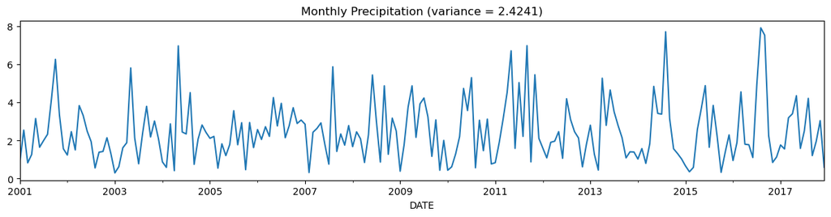

```python
monthly = daily.groupby(pd.Grouper(freq='M')).sum()
ax = monthly.plot(kind='line',figsize=(15,3))
ax.set_title('Monthly Precipitation (variance = %.4f)' % (monthly.var()))
```

```python
annual = daily.groupby(pd.Grouper(freq='Y')).sum()
ax = annual.plot(kind='line',figsize=(15,3))
ax.set_title('Annual Precipitation (variance = %.4f)' % (annual.var()))
```

[output not shown]

### 6. Түүвэрлэлт - Sampling

Түүвэрлэлт нь өгөгдлийн хэмжээг багасгаж хялбар болгоход түгээмэл хэрэглэгддэг арга бөгөөд загварт сургалт явуулахад илүү хялбар болгодог.

Өгөгдлийг түүвэрлэхэд зориулсан янз бүрийн арга байдаг. Жишээ нь:

- Орлуулахгүйгээр түүвэрлэх /sampling without replacement/: Сонгогдсон обьектыг үндсэн өгөгдлийн багцаас устгана
- Орлуулах замаар түүвэрлэх /sampling with replacement/: Сонгогдсон обьектыг үндсэн өгөгдлийн багцаас устгахгүй

Доорх жишээнд бид UCI машин сургалтын сангаас авсан хөхний хорт хавдрын өгөгдлийн багцад орлуулах болон орлуулахгүйгээр түүвэрлэх аргуудыг ашиглана.

Хүснэгтийн эхний таван бичлэгийг харуулсан байна.

```python
data.head()
```

|  | Clump Thickness | Uniformity of Cell Size | Uniformity of Cell Shape | Marginal Adhesion | Single Epithelial Cell Size | Bare Nuclei | Bland Chromatin | Normal Nucleoli | Mitoses | Class |
| --- | --- | --- | --- | --- | --- | --- | --- | --- | --- | --- |
| 0 | 5 | 1 | 1 | 1 | 2 | 1 | 3 | 1 | 1 | 2 |
| 1 | 5 | 4 | 4 | 5 | 7 | 10 | 3 | 2 | 1 | 2 |
| 2 | 3 | 1 | 1 | 1 | 2 | 2 | 3 | 1 | 1 | 2 |
| 3 | 6 | 8 | 8 | 1 | 3 | 4 | 3 | 7 | 1 | 2 |
| 4 | 4 | 1 | 1 | 3 | 2 | 1 | 3 | 1 | 1 | 2 |

Анхны өгөгдлөөс түүврийг санамсаргүй байдлаар (without replacement) сонгох. Энэ тохиолдол түүврийн хэмжээг 3 гэж авсан байна.

```python
sample = data.sample(n=3)
sample
```

Дараагийн жишээнд бид өгөгдлийн 1% -ийг санамсаргүй байдлаар (without replacement) сонгож, сонгосон дээжийг харуулна.

```python
sample = data.sample(frac=0.01, random_state=1)
sample
```

Эцэст нь бүх өгөгдлийн 1% -тай тэнцэх хэмжээний түүвэр үүсгэхийн тулд орлуулалттай түүвэрлэлтийг (with replacement) хийе. Та түүврийн хэмжээг нэмэгдүүлэх замаар түүвэр дэх давхардсан тохиолдлуудыг ажиглах боломжтой.

```python
sample = data.sample(frac=0.01, replace=True, random_state=1)
sample
```

### 7. Дискретчлэл - Discretization

Дискретчлэл нь тасралтгүй утгатай шинж чанарыг категорийн шинж чанар болгон хувиргахад ихэвчлэн ашиглагддаг өгөгдлийг урьдчилан боловсруулалтын алхам юм. Доорх жишээнд хөхний хорт хавдрын өгөгдлийн багцын "Clump Thickness" атрибутад хэрэглэгдэх энгийн боловч өргөн хэрэглэгддэг хяналтгүй (unsupervised) дискретчлэлийн хоёр аргыг **(equal width болон equal depth)** харуулна.

Эхлээд бид атрибутын утгуудын тархалтыг харуулсан гистограммыг зурна. value_counts() функцийг мөн атрибутын утга бүрийн давтамжийг тоолоход ашиглаж болно.

```python
data.describe()
```

```python
data['Clump Thickness'].hist(bins=10)
data['Clump Thickness'].value_counts(sort=False)
```

[output not shown]

**"Equal width"** аргын хувьд **cut()** функцийг ашиглан атрибутыг ижил интервалын өргөнтэй 4 хувинд (bin) хувааж болно. **value_counts()** функцийг хувин бүрт байх тохиолдлуудын тоог тодорхойлоход хэрэглэж болно.

```python
bins = pd.cut(data['Clump Thickness'],4)
bins.value_counts(sort=False)
```

**"Equal frequency"** аргын хувьд **qcut()** функцийг ашиглан утгуудыг 4 хувинд хуваах боломжтой ба хувин бүрт бараг тэнцүү тооны тохиолдлуудтай байна.

```python
bins = pd.qcut(data['Clump Thickness'],4)
bins.value_counts(sort=False)
```

### 8. Үндсэн бүрэлдэхүүн хэсгүүдийн шинжилгээ - Principal Component Analysis (PCA)

Үндсэн бүрэлдэхүүн хэсгүүдийн шинжилгээ (PCA) нь өгөгдлийг анхны өндөр хэмжээст орон зайнаас бага хэмжээст орон зайд проекцлох замаар өгөгдлийн атрибутын тоог багасгах сонгодог арга юм. PCA-н үүсгэсэн шинэ атрибутууд (мөн бүрэлдэхүүн хэсгүүд гэдэг) нь дараах шинж чанаруудтай.

- Тэд анхын атрибутуудын шугаман хослолууд
- Тэдгээр нь хоорондоо перпендикуляр
- Тэд өгөгдлийн хамгийн их өөрчлөлтийг агуулсан байдаг.

Дараах жишээ нь зургийн өгөгдлийн багц дахь PCA-н хэрэглээг харуулна. Энд 16 RGB файл байгаа бөгөөд тус бүр нь 111 x 111 пикселийн хэмжээтэй. Дараах жишээ код нь зургийн файл бүрийг уншиж, RGB зургийг 111 x 111 x 3 = 36963 шинж чанарын утга болгон хувиргана. Энэ нь 16 x 36963 хэмжээтэй өгөгдлийн матрицыг үүсгэх болно.

```python
%matplotlib inline
import matplotlib.pyplot as plt
import matplotlib.image as mpimg
import numpy as np

numImages = 16
fig = plt.figure(figsize=(7,7))
imgData = np.zeros(shape=(numImages,36963))

for i in range(1,numImages+1):
    filename = 'pics/Picture'+str(i)+'.jpg'
    img = mpimg.imread(filename)
    ax = fig.add_subplot(4,4,i)
    plt.imshow(img)
    plt.axis('off')
    ax.set_title(str(i))
    imgData[i-1] = np.array(img.flatten()).reshape(1,img.shape[0]*img.shape[1]*img.shape[2])
```

[output not shown]

PCA-г ашиглан өгөгдлийн матрицыг түүний хамгийн эхний хоёр үндсэн бүрэлдэхүүн хэсэг рүү проекцолно. Анхны зурган өгөгдлийн проекцолсон утгууд нь **projected** нэртэй pandas DataFrame объектод хадгалагдана.

```python
import pandas as pd
from sklearn.decomposition import PCA

numComponents = 2
pca = PCA(n_components=numComponents)
pca.fit(imgData)

projected = pca.transform(imgData)
projected = pd.DataFrame(projected,columns=['pc1','pc2'],index=range(1,numImages+1))
projected['food'] = ['burger', 'burger','burger','burger','drink','drink','drink','drink',
                      'pasta', 'pasta', 'pasta', 'pasta', 'chicken', 'chicken', 'chicken', 'chicken']
projected
```

```python
import matplotlib.pyplot as plt

colors = {'burger':'b', 'drink':'r', 'pasta':'g', 'chicken':'k'}
markerTypes = {'burger':'+', 'drink':'x', 'pasta':'o', 'chicken':'s'}

for foodType in markerTypes:
    d = projected[projected['food']==foodType]
    plt.scatter(d['pc1'],d['pc2'],c=colors[foodType],s=60,marker=markerTypes[foodType])
```

[output not shown]

Энэхүү лабораторийн ажлаар өгөгдөл цэвэрлэх (дутуу утгыг зохицуулах, outlier түүнчлэн давхацсан өгөгдлийг устгах), нэгтгэх, түүвэрлэх, дискретчлэл, үндсэн бүрэлдэхүүн хэсгүүдийн шинжилгээг ашиглан хэмжээст байдлыг багасгах зэрэг өгөгдлийг урьдчилан боловсруулахад зориулсан Python програмчлалын жишээг үзүүллээ.

## Даалгавар

**autompg.csv** өгөгдлийг ашиглан хийх даалгавар. Өгөгдөл нь янз бүрийн машины загваруудын өгөгдлөөс бүрдэх ба хөдөлгүүрийн хэмжээ (engine size), цилиндрийн тоо (number of cylinders), морины хүч (horsepower) болон хурдатгалын (acceleration) утгууд дээр дундаж mpg (miles per gallon) нь үндэслэдэг.

1. Өгөгдлийн эхний 5 мөрийг хэвлэж хар.
2. Бүх атрибутын өгөгдлийн төрлийг хар.
3. Давхцсан мөр байгаа эсэхийг шалгаж, байгаа бол устга.
4. **Дутуу утга** - Дутуу утга байгаа эсэхийг шалгаж, байгаа бол тэдгээр дутуу утгыг атрибутын тархалтаас хамааран дундаж эсвэл медианы утгаар соль.
5. **Хамаарал** - Атрибутын корреляцийн матрицийг үүсгэж, мөн heatmap дүрслэлийг ашиглан атрибутуудын хамаарлыг ажиглана уу.
6. **Хасах талбарууд** - Асуудлын тодорхойлолтод шаардлагагүй багана эсвэл хамааралгүй өгөгдлийг устгах. (Pandas Dataframe drop() функц)
7. **Тооцоолсон талбарууд** - Одоо байгаа шинж чанарууд дээр зарим үйлдлийг хийснээр жинг килограммаар илэрхийлэх шинэ талбар нэмэх, тооцоолоод гаргасан утгыг бүхэл тоо (int) руу хөрвүүлж DataFrame-д нэмнэ. /Жингийн өгөгдсөн утга pound-р илэрхийлэгдсэн байгаа, 1 pound = 0.4535924 kilogram/, (Pandas dataframe insert(), astype() функцүүд)
8. **Шинж чанарыг хэвийн болгох (normalization)** - z онооны аргыг ашиглан шинж чанаруудыг нормчлох.
9. **Outlier** утгыг агуулсан багануудыг тодорхойлохын тулд **boxplot** диаграммыг байгуул.
10. **boxplot** диаграмм дээр дүрслэгдсэн хамгийн их, хамгийн бага утгаас хэтэрсэн (outlier) тохиолдлуудыг устгана. Жишээ нь, Q3 + 1.5×IQR < Z эсвэл Z < Q1 − 1.5×IQR утгатай өгөгдлүүдийг хасна.
11. PCA ашиглан өгөгдлийг 2 хэмжээст рүү хөрвүүлж, бага хэмжээст өгөгдлөө DataFrame обьектод хадгалан хэвлэж харна уу. Дараах материалуудыг ашиглаж болно.

```
https://www.geeksforgeeks.org/implementing-pca-in-python-with-scikit-learn/
https://builtin.com/machine-learning/pca-in-python
```